### Description du ficher csv

Nombre total d'entrées : 309 Colonnes (16 au total) : Catégoriques : GENDER (Genre) : M (Masculin), F (Féminin) LUNG_CANCER : Résultat de dépistage (YES/NO) Numériques : AGE (Âge) Variables binaires ou catégoriques (codées numériquement), telles que : SMOKING (Tabagisme) YELLOW_FINGERS (Doigts jaunes) ANXIETY (Anxiété) PEER_PRESSURE (Pression sociale) CHRONIC DISEASE (Maladie chronique) FATIGUE (Fatigue) ALLERGY (Allergie) WHEEZING (Respiration sifflante) ALCOHOL CONSUMING (Consommation d'alcool) COUGHING (Toux) SHORTNESS OF BREATH (Essoufflement) SWALLOWING DIFFICULTY (Difficulté à avaler) CHEST PAIN (Douleur thoracique)

# Travaille à effectuer

1 Identification de facteurs de risque liés au cancer du poumon Tr = Analyse des facteurs de risque et leur corrélation avec le diagnostic de cancer du poumon. 2 Analyse des symptômes prédominants Tr = Identifier les symptômes les plus fréquents parmi les patients diagnostiqués avec un cancer du poumon. 3 Disparités démographiques (âge et genre) Tr = Étudier l'influence de l'âge et du genre sur la probabilité de développer un cancer du poumon. 4 Analyse des interactions entre les facteurs Tr = Étudier si des combinaisons spécifiques de facteurs (par ex. : tabagisme + fatigue) augmentent significativement le risque.

```python
!pip install pyspark
!pip install matplotlib seaborn
```

```python
from pyspark.sql import SparkSession
import pyspark.sql.functions as F
```

```python
import matplotlib.pyplot as plt
import seaborn as sns
import pandas as pd
```

```python
from pyspark.ml.feature import StringIndexer
from pyspark.ml.feature import VectorAssembler
from pyspark.ml.regression import LinearRegression
```

```python
spark = SparkSession.builder.getOrCreate()
```

# Chargement et Préparation des Données avec PySpark

## Chargement

```python
df = spark.read.csv("survey lung cancer.csv", inferSchema = True, header = True)
## inferSchema=True permet à Spark de deviner automatiquement \
#le type de données de chaque colone du ficher
## header: True permet à PySpark d'utilise la première ligne du fichier comme noms de colonnes
```

```python
df.show(5)
```

```
+------+---+-------+--------------+-------+-------------+---------------+--------+--------+--------+-----------------+--------+-------------------+---------------------+----------+-----------+
|GENDER|AGE|SMOKING|YELLOW_FINGERS|ANXIETY|PEER_PRESSURE|CHRONIC DISEASE|FATIGUE |ALLERGY |WHEEZING|ALCOHOL CONSUMING|COUGHING|SHORTNESS OF BREATH|SWALLOWING DIFFICULTY|CHEST PAIN|LUNG_CANCER|
+------+---+-------+--------------+-------+-------------+---------------+--------+--------+--------+-----------------+--------+-------------------+---------------------+----------+-----------+
|     M| 69|      1|             2|      2|            1|              1|       2|       1|       2|                2|       2|                  2|                    2|         2|        YES|
|     M| 74|      2|             1|      1|            1|              2|       2|       2|       1|                1|       1|                  2|                    2|         2|        YES|
|     F| 59|      1|             1|      1|            2|              1|       2|       1|       2|                1|       2|                  2|                    1|         2|         NO|
|     M| 63|      2|             2|      2|            1|              1|       1|       1|       1|                2|       1|                  1|                    2|         2|         NO|
|     F| 63|      1|             2|      1|            1|              1|       1|       1|       2|                1|       2|                  2|                    1|         1|         NO|
+------+---+-------+--------------+-------+-------------+---------------+--------+--------+--------+-----------------+--------+-------------------+---------------------+----------+-----------+
only showing top 5 rows
```

```python
df.select("GENDER", "AGE","SMOKING","ALCOHOL CONSUMING","SHORTNESS OF BREATH","LUNG_CANCER").show()
```

```
+------+---+-------+-----------------+-------------------+-----------+
|GENDER|AGE|SMOKING|ALCOHOL CONSUMING|SHORTNESS OF BREATH|LUNG_CANCER|
+------+---+-------+-----------------+-------------------+-----------+
|     M| 69|      1|                2|                  2|        YES|
|     M| 74|      2|                1|                  2|        YES|
|     F| 59|      1|                1|                  2|         NO|
|     M| 63|      2|                2|                  1|         NO|
|     F| 63|      1|                1|                  2|         NO|
|     F| 75|      1|                1|                  2|        YES|
|     M| 52|      2|                2|                  2|        YES|
|     F| 51|      2|                1|                  2|        YES|
|     F| 68|      2|                1|                  1|         NO|
|     M| 53|      2|                2|                  1|        YES|
|     F| 61|      2|                1|                  2|        YES|
|     M| 72|      1|                2|                  2|        YES|
|     F| 60|      2|                1|                  2|         NO|
|     M| 58|      2|                2|                  2|        YES|
|     M| 69|      2|                2|                  1|         NO|
|     F| 48|      1|                1|                  2|        YES|
|     M| 75|      2|                2|                  2|        YES|
|     M| 57|      2|                2|                  1|        YES|
|     F| 68|      2|                1|                  2|        YES|
|     F| 61|      1|                1|                  2|         NO|
+------+---+-------+-----------------+-------------------+-----------+
only showing top 20 rows
```

### A cause de la mal visualisation de la base nous avons renomé le nom de certains columns pour une excellente visualisation

```python
## Renomage de certains colomn de la basse de données
df = df.withColumnRenamed("YELLOW_FINGERS", "FINGERS")
df = df.withColumnRenamed("CHRONIC DISEASE", "DISEASE")
df = df.withColumnRenamed("PEER_PRESSURE", "PRESSURE")
df = df.withColumnRenamed("FATIGUE ", "FATIGUE")
df = df.withColumnRenamed("ALLERGY ", "ALLERGY")
df = df.withColumnRenamed("ALCOHOL CONSUMING", "ALCOHOL")
df = df.withColumnRenamed("SHORTNESS OF BREATH", "BREATH")
df = df.withColumnRenamed("SWALLOWING DIFFICULTY", "SWALLOWING")
df = df.withColumnRenamed("CHEST PAIN", "PAIN")
df = df.withColumnRenamed("LUNG_CANCER", "CANCER")
```

```python
df.show(5)
```

```
+------+---+-------+-------+-------+--------+-------+-------+-------+--------+-------+--------+------+----------+----+------+
|GENDER|AGE|SMOKING|FINGERS|ANXIETY|PRESSURE|DISEASE|FATIGUE|ALLERGY|WHEEZING|ALCOHOL|COUGHING|BREATH|SWALLOWING|PAIN|CANCER|
+------+---+-------+-------+-------+--------+-------+-------+-------+--------+-------+--------+------+----------+----+------+
|     M| 69|      1|      2|      2|       1|      1|      2|      1|       2|      2|       2|     2|         2|   2|   YES|
|     M| 74|      2|      1|      1|       1|      2|      2|      2|       1|      1|       1|     2|         2|   2|   YES|
|     F| 59|      1|      1|      1|       2|      1|      2|      1|       2|      1|       2|     2|         1|   2|    NO|
|     M| 63|      2|      2|      2|       1|      1|      1|      1|       1|      2|       1|     1|         2|   2|    NO|
|     F| 63|      1|      2|      1|       1|      1|      1|      1|       2|      1|       2|     2|         1|   1|    NO|
+------+---+-------+-------+-------+--------+-------+-------+-------+--------+-------+--------+------+----------+----+------+
only showing top 5 rows
```

## Préparation des Données

```python
## Vérification des valeurs manquantes
df.select([F.count(F.when(F.col(c).isNull(), c)).alias(c) for c in df.columns]).show()
```

```
+------+---+-------+-------+-------+--------+-------+-------+-------+--------+-------+--------+------+----------+----+------+
|GENDER|AGE|SMOKING|FINGERS|ANXIETY|PRESSURE|DISEASE|FATIGUE|ALLERGY|WHEEZING|ALCOHOL|COUGHING|BREATH|SWALLOWING|PAIN|CANCER|
+------+---+-------+-------+-------+--------+-------+-------+-------+--------+-------+--------+------+----------+----+------+
|     0|  0|      0|      0|      0|       0|      0|      0|      0|       0|      0|       0|     0|         0|   0|     0|
+------+---+-------+-------+-------+--------+-------+-------+-------+--------+-------+--------+------+----------+----+------+
```

### Pourquoi nous avons pas traité les valeurs dupliqués :

```
Certe il y'a des valeurs dubliqués comme Genre=M, Age=45, Smoking=Yes qu'on retrouve 2 fois dans la base Mais c'est pas
toute la ligne qui est pareil les autres column de c'est deux ligne sont différents
```

## Transformation des données

```python
## Affichage des type des variable initial
df.printSchema()
```

```
root
 |-- GENDER: string (nullable = true)
 |-- AGE: integer (nullable = true)
 |-- SMOKING: integer (nullable = true)
 |-- FINGERS: integer (nullable = true)
 |-- ANXIETY: integer (nullable = true)
 |-- PRESSURE: integer (nullable = true)
 |-- DISEASE: integer (nullable = true)
 |-- FATIGUE: integer (nullable = true)
 |-- ALLERGY: integer (nullable = true)
 |-- WHEEZING: integer (nullable = true)
 |-- ALCOHOL: integer (nullable = true)
 |-- COUGHING: integer (nullable = true)
 |-- BREATH: integer (nullable = true)
 |-- SWALLOWING: integer (nullable = true)
 |-- PAIN: integer (nullable = true)
 |-- CANCER: string (nullable = true)
```

### Changement du type des variable :

```
VectorAssembler prend en compte que les type numérique
```

```python
###Pour tranformer le non pour les colunms
genderindexer = StringIndexer(inputCol="GENDER", outputCol="SEX")
df = genderindexer.fit(df).transform(df)
```

```python
### Changement selon nos choix de base sa le mets en double, nous le changeons en integer avec nos prope valeurs
df = df.withColumn("SEX",
                   F.when(F.col("GENDER") == "M", 1)
                    .when(F.col("GENDER") == "F", 2)
                    .otherwise(-1)) # Valeur par défaut si autre chose que 'M' ou 'F'
```

```python
lung_indexer = StringIndexer(inputCol="CANCER", outputCol="IF_CANCER")
df = lung_indexer.fit(df).transform(df)
```

```python
### Changement selon mes choix
df = df.withColumn("IF_CANCER",
                   F.when(F.col("CANCER") == "NO", 0)
                    .when(F.col("CANCER") == "YES", 1)
                    .otherwise(-1)) # Valeur par défaut si autre chose que 'YES' ou 'NO'
```

```python
### Type des variables après transformation
df.printSchema()
```

```
root
 |-- GENDER: string (nullable = true)
 |-- AGE: integer (nullable = true)
 |-- SMOKING: integer (nullable = true)
 |-- FINGERS: integer (nullable = true)
 |-- ANXIETY: integer (nullable = true)
 |-- PRESSURE: integer (nullable = true)
 |-- DISEASE: integer (nullable = true)
 |-- FATIGUE: integer (nullable = true)
 |-- ALLERGY: integer (nullable = true)
 |-- WHEEZING: integer (nullable = true)
 |-- ALCOHOL: integer (nullable = true)
 |-- COUGHING: integer (nullable = true)
 |-- BREATH: integer (nullable = true)
 |-- SWALLOWING: integer (nullable = true)
 |-- PAIN: integer (nullable = true)
 |-- CANCER: string (nullable = true)
 |-- SEX: integer (nullable = false)
 |-- IF_CANCER: integer (nullable = false)
```

```python
### Affichage des columns
print(df.columns)
```

```
['GENDER', 'AGE', 'SMOKING', 'FINGERS', 'ANXIETY', 'PRESSURE', 'DISEASE', 'FATIGUE', 'ALLERGY', 'WHEEZING', 'ALCOHOL', 'COUGHING', 'BREATH', 'SWALLOWING', 'PAIN', 'CANCER', 'SEX', 'IF_CANCER']
```

```python
### Etape de préparation des données pour l'entraînement d'un modèle de machine learning
assembler = VectorAssembler(inputCols= ["AGE", "SMOKING", "FINGERS", "ANXIETY", "PRESSURE", "DISEASE",
                                        "FATIGUE", "ALLERGY", "WHEEZING","ALCOHOL", "COUGHING", "BREATH",
                                        "SWALLOWING", "PAIN", "SEX", "IF_CANCER"],
                           outputCol= "features")
```

```python
assembler
```

```
VectorAssembler_6c7ad07af297
```

```python
### Stockage dans une variable
output = assembler.transform(df)
```

```python
output.select("features","SMOKING").show()
```

```
+--------------------+-------+
|            features|SMOKING|
+--------------------+-------+
|[69.0,1.0,2.0,2.0...|      1|
|[74.0,2.0,1.0,1.0...|      2|
|[59.0,1.0,1.0,1.0...|      1|
|[63.0,2.0,2.0,2.0...|      2|
|[63.0,1.0,2.0,1.0...|      1|
|[75.0,1.0,2.0,1.0...|      1|
|[52.0,2.0,1.0,1.0...|      2|
|[51.0,2.0,2.0,2.0...|      2|
|[68.0,2.0,1.0,2.0...|      2|
|[53.0,2.0,2.0,2.0...|      2|
|[61.0,2.0,2.0,2.0...|      2|
|[72.0,1.0,1.0,1.0...|      1|
|[60.0,2.0,1.0,1.0...|      2|
|[58.0,2.0,1.0,1.0...|      2|
|[69.0,2.0,1.0,1.0...|      2|
|[48.0,1.0,2.0,2.0...|      1|
|[75.0,2.0,1.0,1.0...|      2|
|[57.0,2.0,2.0,2.0...|      2|
|[68.0,2.0,2.0,2.0...|      2|
|[61.0,1.0,1.0,1.0...|      1|
+--------------------+-------+
only showing top 20 rows
```

# Analyse Exploratoire des Données

## Analyse descriptive

```python
## statistiques descriptives
df.describe("GENDER","AGE","SMOKING").show()
```

```
+-------+------+-----------------+------------------+
|summary|GENDER|              AGE|           SMOKING|
+-------+------+-----------------+------------------+
|  count|   309|              309|               309|
|   mean|  NULL|62.67313915857605|1.5631067961165048|
| stddev|  NULL|8.210301387885995|0.4968060894409518|
|    min|     F|               21|                 1|
|    max|     M|               87|                 2|
+-------+------+-----------------+------------------+
```

```python
## Nombre de lignes dans ma base de donneés
df.count()
## Nombre de personne fument
df.filter(F.col("SMOKING") == 1).count()
## Nombre de personne non fument
df.filter(F.col("SMOKING") == 2).count()
```

```
174
```

```python
## Liste pour afficher le nom des column
len(df.columns)
```

```
18
```

```python
## Nombre de personne par age
df.groupBy("AGE").count().show()
```

```
+---+-----+
|AGE|count|
+---+-----+
| 65|    7|
| 53|    4|
| 78|    2|
| 81|    2|
| 76|    4|
| 44|    2|
| 47|    4|
| 52|    4|
| 57|    9|
| 54|    8|
| 48|    2|
| 64|   20|
| 61|   16|
| 72|   10|
| 59|   15|
| 55|   11|
| 39|    1|
| 49|    3|
| 87|    1|
| 51|    8|
+---+-----+
only showing top 20 rows
```

```python
## Nombre de famme et homme
df.groupBy("Gender").count().show()
```

```
+------+-----+
|Gender|count|
+------+-----+
|     F|  147|
|     M|  162|
+------+-----+
```

```python
df.groupBy("SMOKING").count().show()
```

```
+-------+-----+
|SMOKING|count|
+-------+-----+
|      1|  135|
|      2|  174|
+-------+-----+
```

## Visualisation exploratoire

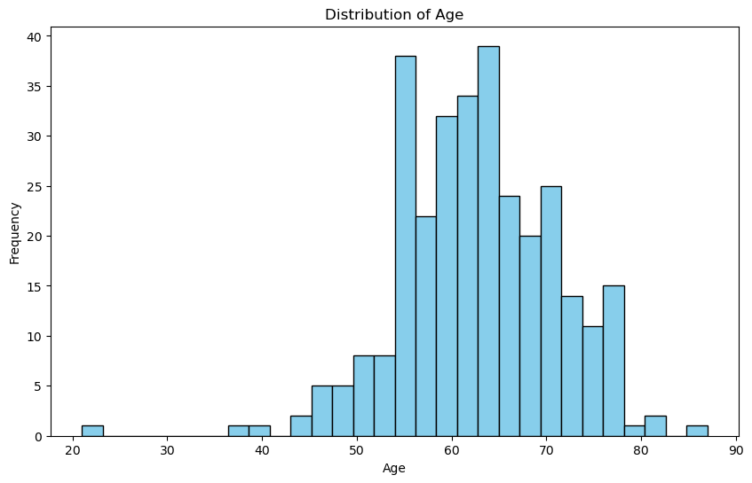

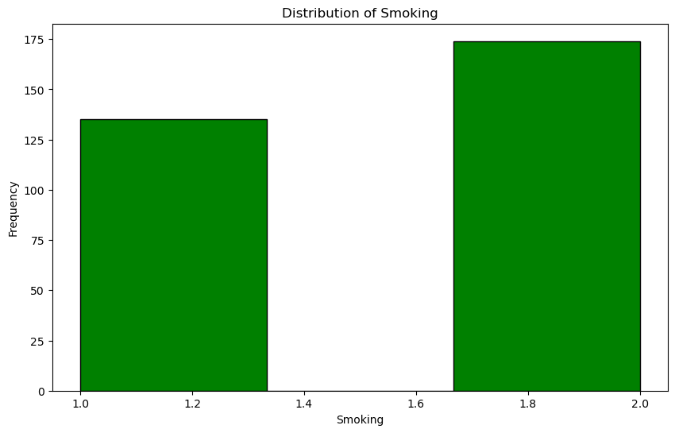

```python
### Histogramme pour visualiser la distribution des variable telles que l'âge et le tabagisme

# Convertion de la column en Pandas DataFrame pour l'âge
age_df = df.select("AGE").toPandas()

# Tracer l'histogramme de l'âge
plt.figure(figsize=(10, 6))
plt.hist(age_df['AGE'], bins=30, color='skyblue', edgecolor='black')
plt.title('Distribution of Age')
plt.xlabel('Age')
plt.ylabel('Frequency')
plt.show()

# Convertion de la column en Pandas DataFrame pour le tabagisme
smoking_df = df.select("SMOKING").toPandas()

# Tracer l'histogramme du tabagisme
plt.figure(figsize=(10, 6))
plt.hist(smoking_df['SMOKING'], bins=3, color='green', edgecolor='black')  # SMOKING est une variable catégorielle
plt.title('Distribution of Smoking')
plt.xlabel('Smoking')
plt.ylabel('Frequency')
plt.show()
```

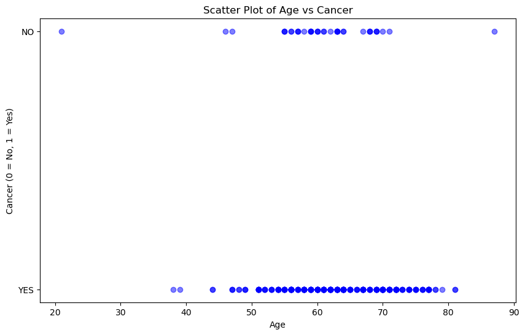

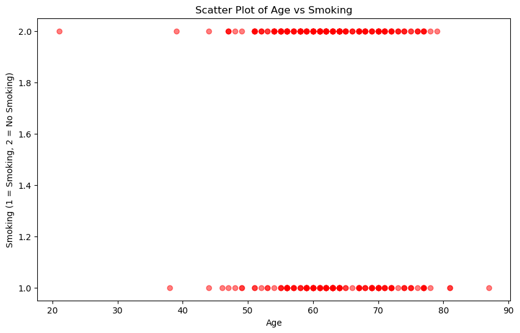

```python
### Diagramme pour examiner la relation entre les variables

## Diagramme de dispersion entre Age et LUNG_CANCER (l'âge et le cancer du poumon)
cancer_df = df.select("AGE", "CANCER").toPandas()

plt.figure(figsize=(10, 6))
plt.scatter(cancer_df['AGE'], cancer_df['CANCER'], color='blue', alpha=0.5)
plt.title('Scatter Plot of Age vs Cancer')
plt.xlabel('Age')
plt.ylabel('Cancer (0 = No, 1 = Yes)')
plt.show()

## Diagramme de dispersion entre Age et Smoking (l'âge et le tabagisme)
smoking_df = df.select("AGE", "SMOKING").toPandas()

plt.figure(figsize=(10, 6))
plt.scatter(smoking_df['AGE'], smoking_df['SMOKING'], color='red', alpha=0.5)
plt.title('Scatter Plot of Age vs Smoking')
plt.xlabel('Age')
plt.ylabel('Smoking (1 = Smoking, 2 = No Smoking)')
plt.show()
```

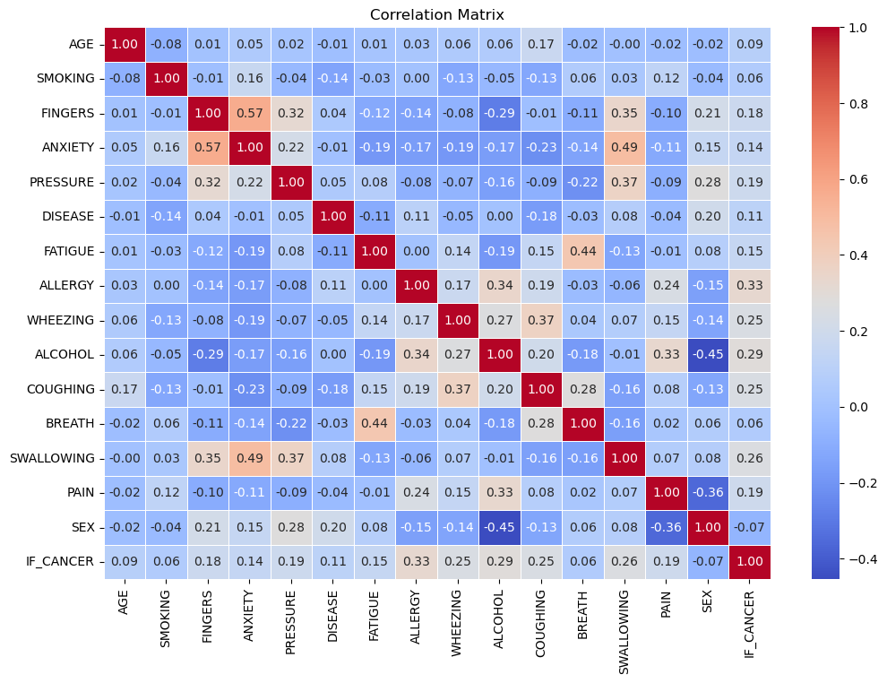

```python
### Matrice de corrélation pour examiner les relations linéaires entre toutes les variables

## Convertion en DataFrame Pandas
df_pandas = df.select("AGE", "SMOKING", "FINGERS", "ANXIETY", "PRESSURE", "DISEASE", "FATIGUE", "ALLERGY",
                      "WHEEZING","ALCOHOL", "COUGHING", "BREATH","SWALLOWING", "PAIN", "SEX", "IF_CANCER").toPandas()

## Calculer la matrice de corrélation
corr = df_pandas.corr()

## Tracer la matrice de corrélation
plt.figure(figsize=(12, 8))
sns.heatmap(corr, annot=True, cmap="coolwarm", fmt=".2f", linewidths=0.5)
plt.title('Correlation Matrix')
plt.show()
```

# Modélisation avec Régression Linéaire en PySpark

## Division des données

#### Ici le model est comparer par rapport au Smoking(fumeur)

```python
## Model
modelDf = output.select("features", "SMOKING")
```

```python
modelDf.show()
```

```
+--------------------+-------+
|            features|SMOKING|
+--------------------+-------+
|[69.0,1.0,2.0,2.0...|      1|
|[74.0,2.0,1.0,1.0...|      2|
|[59.0,1.0,1.0,1.0...|      1|
|[63.0,2.0,2.0,2.0...|      2|
|[63.0,1.0,2.0,1.0...|      1|
|[75.0,1.0,2.0,1.0...|      1|
|[52.0,2.0,1.0,1.0...|      2|
|[51.0,2.0,2.0,2.0...|      2|
|[68.0,2.0,1.0,2.0...|      2|
|[53.0,2.0,2.0,2.0...|      2|
|[61.0,2.0,2.0,2.0...|      2|
|[72.0,1.0,1.0,1.0...|      1|
|[60.0,2.0,1.0,1.0...|      2|
|[58.0,2.0,1.0,1.0...|      2|
|[69.0,2.0,1.0,1.0...|      2|
|[48.0,1.0,2.0,2.0...|      1|
|[75.0,2.0,1.0,1.0...|      2|
|[57.0,2.0,2.0,2.0...|      2|
|[68.0,2.0,2.0,2.0...|      2|
|[61.0,1.0,1.0,1.0...|      1|
+--------------------+-------+
only showing top 20 rows
```

```python
## Division des données en ensembles d'entraînement et de test (80% pour l'entraînement, 20% pour le test)
trainDf, testDf = modelDf.randomSplit([0.8, 0.2])

## Vérification du nombre d'exemples dans chaque ensemble
print("Ensemble d'entraînement : ", trainDf.count())
print("Ensemble de test : ", testDf.count())
```

```
Ensemble d'entraînement :  231
Ensemble de test :  78
```

## Création du modèle

```python
## Créer le modèle de régression linéaire
lr = LinearRegression(featuresCol="features", labelCol="SMOKING")

## Entraîner le modèle avec les données d'entraînement
lr_model = lr.fit(trainDf)

# Afficher les coefficients du modèle
print("Coefficients : ", lr_model.coefficients)
print("Ordonnée à l'origine : ", lr_model.intercept)
```

[output not shown]

## Évaluation

```python
## Effectuer des prédictions sur l'ensemble de test
test_results = lr_model.evaluate(testDf)

## Afficher les métriques de performance
print("MSE (Mean Squared Error) : ", test_results.meanSquaredError)
print("RMSE (Root Mean Squared Error) : ", test_results.rootMeanSquaredError)
print("MAE (Mean Absolute Error) : ", test_results.meanAbsoluteError)
```

```
MSE (Mean Squared Error) :  1.1883481585060113e-31
RMSE (Root Mean Squared Error) :  3.447242606063593e-16
MAE (Mean Absolute Error) :  3.0744637605004334e-16
```

# Analyse Explicative et Visualisation des Résultats

## Visualisation des prédictions

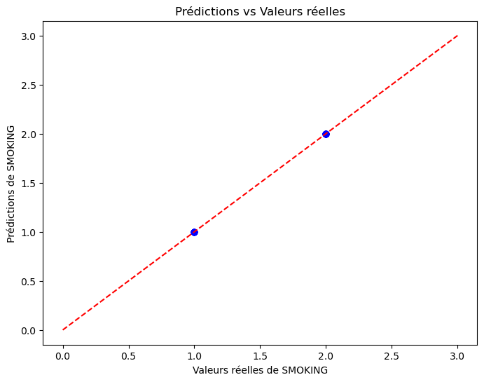

```python
## Récupération des résultats dans un DataFrame Pandas pour la visualisation
predictions = test_results.predictions.select("SMOKING", "prediction").toPandas()

## Visualisation des prédictions vs valeurs réelles
plt.figure(figsize=(8, 6))
plt.scatter(predictions["SMOKING"], predictions["prediction"], color='blue', alpha=0.5)
plt.plot([0, 3], [0, 3], color='red', linestyle='--')
plt.title("Prédictions vs Valeurs réelles")
plt.xlabel("Valeurs réelles de SMOKING")
plt.ylabel("Prédictions de SMOKING")
plt.show()
```

#### A ne pas prendre en compte ce sont des teste à part, n'inclut pas dans le project

pt = results[(results.SMOKING == 1) & (results.prediction == 1)].count() pts = results[(results.SMOKING == 2) & (results.prediction == 2)].count()

pt pts

acc = float((pt+pts)/ (results.count())) print(acc)

###### Collect the predictions from the results DataFrame

results_pd = results.select("SMOKING", "prediction").toPandas()